# Week 11 - Introduction to Modeling, part 2

# 1. Lesson - No lesson this week

# 2. Weekly graph question

```python
import pandas as pd
import numpy as np
from sklearn.ensemble import RandomForestRegressor
from sklearn.metrics import root_mean_squared_error
from sklearn.model_selection import GridSearchCV
from sklearn.metrics import make_scorer
from sklearn.pipeline import make_pipeline
from sklearn.preprocessing import StandardScaler
from sklearn.model_selection import RepeatedKFold
from sklearn.model_selection import cross_val_score
from sklearn.metrics import classification_report
```

The book names one of Vonnegut's rules as "keep it simple" and another as "have the guts to cut." Here is some data from the previous week's lesson. If you had to cut one of the two plots below, which would it be? Which seems more interesting or important? Explain. (Should "amount of training data used" or "number of estimators" be on the x-axis.)

```python
np.random.seed(0)
num_points = 10000
feature_1a = np.random.random(size = num_points) * 3
feature_2a = np.random.random(size = num_points) * 3
feature_3a = np.random.random(size = num_points) * 3
train_target = (feature_1a - 2 * feature_2a) * feature_3a + np.random.normal(size = num_points)
feature_1b = np.random.random(size = num_points) * 3
feature_2b = np.random.random(size = num_points) * 3
feature_3b = np.random.random(size = num_points) * 3
test_target = (feature_1b - 2 * feature_2b) * feature_3b + np.random.normal(size = num_points)
train_df = pd.DataFrame({"f1": feature_1a, "f2": feature_2a, "f3": feature_3a})
test_df = pd.DataFrame({"f1": feature_1b, "f2": feature_2b, "f3": feature_3b})
rf = RandomForestRegressor()
rf.fit(train_df.values, train_target)
```

```
RandomForestRegressor()
```

```python
rmse_lst = list()
rf = RandomForestRegressor()
for x in range(round(num_points / 20), num_points, round(num_points / 20)):
    rf.fit(train_df.values[0:x,:], train_target[0:x])
    rmse_lst.append(root_mean_squared_error(rf.predict(test_df.values), test_target))

import matplotlib.pyplot as plt
```

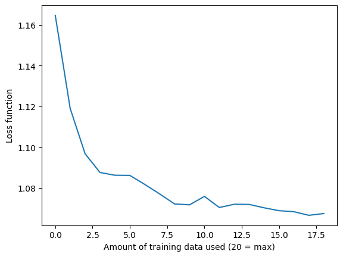

```python
plt.plot(rmse_lst)
plt.xlabel("Amount of training data used (20 = max)")
plt.ylabel("Loss function")
```

```python
num_trees_lst = list()
for n_estimators in range(1, 100, 3):
    rf = RandomForestRegressor(n_estimators = n_estimators)
    rf.fit(train_df.values, train_target)
    num_trees_lst.append(root_mean_squared_error(rf.predict(test_df.values), test_target))
```

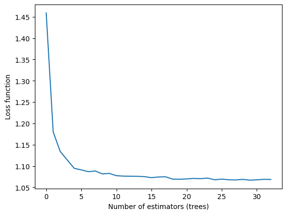

```python
plt.plot(num_trees_lst)
plt.xlabel("Number of estimators (trees)")
plt.ylabel("Loss function")
```

# 3. Working on your datasets

This week, you will do the same types of exercises as last week, but you should use your chosen datasets that someone in your class found last semester. (They likely will not be the particular datasets that you found yourself.)

Here are some types of analysis you can do:

- Implement a random forest model.
- Perform cross-validation.
- Tune hyperparameters.
- Evaluate a performance metric.

If you like, you can try other types of models, too (beyond linear regression and random forest) although you will have many opportunities to do that next semester.

```python
df = pd.read_csv('Milestone 3 EDA/ibm_hi_small_trans_cleaned.csv')
df
```

|  | Timestamp | From Bank | Account | To Bank | Account.1 | Amount Received | Amount Paid | Is Laundering | Amount_Received_USD | Amount_Paid_USD | ... | Payment Currency_Yuan | Payment Format_ACH | Payment Format_Bitcoin | Payment Format_Cash | Payment Format_Cheque | Payment Format_Credit Card | Payment Format_Reinvestment | Payment Format_Wire | Account_Same | Bank_Same |
| --- | --- | --- | --- | --- | --- | --- | --- | --- | --- | --- | --- | --- | --- | --- | --- | --- | --- | --- | --- | --- | --- |
| 0 | 2022/09/01 00:20 | 10 | 8000EBD30 | 10 | 8000EBD30 | 3697.340000 | 3697.340000 | 0 | 3697.340000 | 3697.340000 | ... | 0.0 | 0.0 | 0.0 | 0.0 | 0.0 | 0.0 | 1.0 | 0.0 | 1 | 1 |
| 1 | 2022/09/01 00:20 | 3208 | 8000F4580 | 1 | 8000F5340 | 0.010000 | 0.010000 | 0 | 0.010000 | 0.010000 | ... | 0.0 | 0.0 | 0.0 | 0.0 | 1.0 | 0.0 | 0.0 | 0.0 | 0 | 0 |
| 2 | 2022/09/01 00:00 | 3209 | 8000F4670 | 3209 | 8000F4670 | 14675.570000 | 14675.570000 | 0 | 14675.570000 | 14675.570000 | ... | 0.0 | 0.0 | 0.0 | 0.0 | 0.0 | 0.0 | 1.0 | 0.0 | 1 | 1 |
| 3 | 2022/09/01 00:02 | 12 | 8000F5030 | 12 | 8000F5030 | 2806.970000 | 2806.970000 | 0 | 2806.970000 | 2806.970000 | ... | 0.0 | 0.0 | 0.0 | 0.0 | 0.0 | 0.0 | 1.0 | 0.0 | 1 | 1 |
| 4 | 2022/09/01 00:06 | 10 | 8000F5200 | 10 | 8000F5200 | 36682.970000 | 36682.970000 | 0 | 36682.970000 | 36682.970000 | ... | 0.0 | 0.0 | 0.0 | 0.0 | 0.0 | 0.0 | 1.0 | 0.0 | 1 | 1 |
| ... | ... | ... | ... | ... | ... | ... | ... | ... | ... | ... | ... | ... | ... | ... | ... | ... | ... | ... | ... | ... | ... |
| 5078340 | 2022/09/10 23:57 | 54219 | 8148A6631 | 256398 | 8148A8711 | 0.154978 | 0.154978 | 0 | 3107.386389 | 3107.386389 | ... | 0.0 | 0.0 | 1.0 | 0.0 | 0.0 | 0.0 | 0.0 | 0.0 | 0 | 0 |
| 5078341 | 2022/09/10 23:35 | 15 | 8148A8671 | 256398 | 8148A8711 | 0.108128 | 0.108128 | 0 | 2168.020464 | 2168.020464 | ... | 0.0 | 0.0 | 1.0 | 0.0 | 0.0 | 0.0 | 0.0 | 0.0 | 0 | 0 |
| 5078342 | 2022/09/10 23:52 | 154365 | 8148A6771 | 256398 | 8148A8711 | 0.004988 | 0.004988 | 0 | 100.011894 | 100.011894 | ... | 0.0 | 0.0 | 1.0 | 0.0 | 0.0 | 0.0 | 0.0 | 0.0 | 0 | 0 |
| 5078343 | 2022/09/10 23:46 | 256398 | 8148A6311 | 256398 | 8148A8711 | 0.038417 | 0.038417 | 0 | 770.280058 | 770.280058 | ... | 0.0 | 0.0 | 1.0 | 0.0 | 0.0 | 0.0 | 0.0 | 0.0 | 0 | 1 |
| 5078344 | 2022/09/10 23:37 | 154518 | 8148A6091 | 256398 | 8148A8711 | 0.281983 | 0.281983 | 0 | 5653.900141 | 5653.900141 | ... | 0.0 | 0.0 | 1.0 | 0.0 | 0.0 | 0.0 | 0.0 | 0.0 | 0 | 0 |

5078345 rows × 109 columns

```python
df.columns
```

```
Index(['Timestamp', 'From Bank', 'Account', 'To Bank', 'Account.1',
       'Amount Received', 'Amount Paid', 'Is Laundering',
       'Amount_Received_USD', 'Amount_Paid_USD',
       ...
       'Payment Currency_Yuan', 'Payment Format_ACH', 'Payment Format_Bitcoin',
       'Payment Format_Cash', 'Payment Format_Cheque',
       'Payment Format_Credit Card', 'Payment Format_Reinvestment',
       'Payment Format_Wire', 'Account_Same', 'Bank_Same'],
      dtype='object', length=109)
```

```python
df.drop(columns=['Timestamp', 'From Bank', 'To Bank', 'Account', 'Account.1'], inplace=True)
```

```python
df.info()
```

```
<class 'pandas.core.frame.DataFrame'>
RangeIndex: 5078345 entries, 0 to 5078344
Columns: 104 entries, Amount Received to Bank_Same
dtypes: float64(101), int64(3)
memory usage: 3.9 GB
```

```python
random_state = 42
```

```python
fraud = df[df['Is Laundering'] == 1]
non_fraud = df[df['Is Laundering'] == 0]
len(fraud), len(non_fraud)
```

```
(5177, 5073168)
```

```python
# Undersample majority class to a 1:10 ratio
non_fraud_downsampled = non_fraud.sample(n=len(fraud) * 10, random_state=random_state)
non_fraud_downsampled
```

|  | Amount Received | Amount Paid | Is Laundering | Amount_Received_USD | Amount_Paid_USD | US Dollar_Amount_Paid_Mean | US Dollar_Amount_Paid_Median | US Dollar_Amount_Received_Mean | US Dollar_Amount_Received_Median | Bitcoin_Amount_Paid_Mean | ... | Payment Currency_Yuan | Payment Format_ACH | Payment Format_Bitcoin | Payment Format_Cash | Payment Format_Cheque | Payment Format_Credit Card | Payment Format_Reinvestment | Payment Format_Wire | Account_Same | Bank_Same |
| --- | --- | --- | --- | --- | --- | --- | --- | --- | --- | --- | --- | --- | --- | --- | --- | --- | --- | --- | --- | --- | --- |
| 4563287 | 1439.79 | 1439.79 | 0 | 3.829841e+02 | 3.829841e+02 | 367153.780541 | 904.13 | 4.041979e+06 | 908.2 | 20.809275 | ... | 0.0 | 0.0 | 0.0 | 0.0 | 0.0 | 1.0 | 0.0 | 0.0 | 0 | 0 |
| 4216770 | 33.09 | 33.09 | 0 | 3.309000e+01 | 3.309000e+01 | 367153.780541 | 904.13 | 4.041979e+06 | 908.2 | 20.809275 | ... | 0.0 | 0.0 | 0.0 | 0.0 | 0.0 | 1.0 | 0.0 | 0.0 | 0 | 0 |
| 2992877 | 263.34 | 263.34 | 0 | 3.807896e+01 | 3.807896e+01 | 367153.780541 | 904.13 | 4.041979e+06 | 908.2 | 20.809275 | ... | 1.0 | 1.0 | 0.0 | 0.0 | 0.0 | 0.0 | 0.0 | 0.0 | 0 | 0 |
| 1499016 | 17154983.76 | 17154983.76 | 0 | 1.747064e+07 | 1.747064e+07 | 367153.780541 | 904.13 | 4.041979e+06 | 908.2 | 20.809275 | ... | 0.0 | 0.0 | 0.0 | 0.0 | 1.0 | 0.0 | 0.0 | 0.0 | 0 | 0 |
| 510282 | 8499.22 | 8499.22 | 0 | 2.501320e+03 | 2.501320e+03 | 367153.780541 | 904.13 | 4.041979e+06 | 908.2 | 20.809275 | ... | 0.0 | 0.0 | 0.0 | 0.0 | 1.0 | 0.0 | 0.0 | 0.0 | 0 | 0 |
| ... | ... | ... | ... | ... | ... | ... | ... | ... | ... | ... | ... | ... | ... | ... | ... | ... | ... | ... | ... | ... | ... |
| 3992741 | 5722.87 | 5722.87 | 0 | 5.722870e+03 | 5.722870e+03 | 367153.780541 | 904.13 | 4.041979e+06 | 908.2 | 20.809275 | ... | 0.0 | 0.0 | 0.0 | 0.0 | 1.0 | 0.0 | 0.0 | 0.0 | 0 | 0 |
| 44465 | 82208.92 | 82208.92 | 0 | 8.220892e+04 | 8.220892e+04 | 367153.780541 | 904.13 | 4.041979e+06 | 908.2 | 20.809275 | ... | 0.0 | 0.0 | 0.0 | 1.0 | 0.0 | 0.0 | 0.0 | 0.0 | 0 | 0 |
| 1173046 | 6837.09 | 6837.09 | 0 | 5.196872e+03 | 5.196872e+03 | 367153.780541 | 904.13 | 4.041979e+06 | 908.2 | 20.809275 | ... | 0.0 | 0.0 | 0.0 | 0.0 | 0.0 | 1.0 | 0.0 | 0.0 | 0 | 0 |
| 4125810 | 3261.27 | 3261.27 | 0 | 3.763506e+03 | 3.763506e+03 | 367153.780541 | 904.13 | 4.041979e+06 | 908.2 | 20.809275 | ... | 0.0 | 0.0 | 0.0 | 0.0 | 0.0 | 0.0 | 0.0 | 1.0 | 0 | 0 |
| 3821365 | 20287.92 | 20287.92 | 0 | 2.933633e+03 | 2.933633e+03 | 367153.780541 | 904.13 | 4.041979e+06 | 908.2 | 20.809275 | ... | 1.0 | 1.0 | 0.0 | 0.0 | 0.0 | 0.0 | 0.0 | 0.0 | 0 | 0 |

51770 rows × 104 columns

```python
# Combine and shuffle
df_reduced = pd.concat([fraud, non_fraud_downsampled]).sample(frac=1).reset_index(drop=True)
df_reduced
```

|  | Amount Received | Amount Paid | Is Laundering | Amount_Received_USD | Amount_Paid_USD | US Dollar_Amount_Paid_Mean | US Dollar_Amount_Paid_Median | US Dollar_Amount_Received_Mean | US Dollar_Amount_Received_Median | Bitcoin_Amount_Paid_Mean | ... | Payment Currency_Yuan | Payment Format_ACH | Payment Format_Bitcoin | Payment Format_Cash | Payment Format_Cheque | Payment Format_Credit Card | Payment Format_Reinvestment | Payment Format_Wire | Account_Same | Bank_Same |
| --- | --- | --- | --- | --- | --- | --- | --- | --- | --- | --- | --- | --- | --- | --- | --- | --- | --- | --- | --- | --- | --- |
| 0 | 142.21 | 142.21 | 0 | 141.427845 | 141.427845 | 367153.780541 | 904.13 | 4.041979e+06 | 908.2 | 20.809275 | ... | 0.0 | 0.0 | 0.0 | 0.0 | 1.0 | 0.0 | 0.0 | 0.0 | 0 | 0 |
| 1 | 8.12 | 8.12 | 0 | 8.269408 | 8.269408 | 367153.780541 | 904.13 | 4.041979e+06 | 908.2 | 20.809275 | ... | 0.0 | 0.0 | 0.0 | 0.0 | 0.0 | 0.0 | 1.0 | 0.0 | 1 | 1 |
| 2 | 234.56 | 234.56 | 0 | 233.269920 | 233.269920 | 367153.780541 | 904.13 | 4.041979e+06 | 908.2 | 20.809275 | ... | 0.0 | 0.0 | 0.0 | 0.0 | 1.0 | 0.0 | 0.0 | 0.0 | 0 | 0 |
| 3 | 19640.00 | 19640.00 | 0 | 20001.376000 | 20001.376000 | 367153.780541 | 904.13 | 4.041979e+06 | 908.2 | 20.809275 | ... | 0.0 | 0.0 | 0.0 | 0.0 | 0.0 | 1.0 | 0.0 | 0.0 | 0 | 0 |
| 4 | 8.38 | 8.38 | 0 | 8.380000 | 8.380000 | 367153.780541 | 904.13 | 4.041979e+06 | 908.2 | 20.809275 | ... | 0.0 | 1.0 | 0.0 | 0.0 | 0.0 | 0.0 | 0.0 | 0.0 | 0 | 0 |
| ... | ... | ... | ... | ... | ... | ... | ... | ... | ... | ... | ... | ... | ... | ... | ... | ... | ... | ... | ... | ... | ... |
| 56942 | 78922.59 | 78922.59 | 0 | 3906.668205 | 3906.668205 | 367153.780541 | 904.13 | 4.041979e+06 | 908.2 | 20.809275 | ... | 0.0 | 0.0 | 0.0 | 0.0 | 0.0 | 1.0 | 0.0 | 0.0 | 0 | 0 |
| 56943 | 89535.13 | 89535.13 | 0 | 635.699423 | 635.699423 | 367153.780541 | 904.13 | 4.041979e+06 | 908.2 | 20.809275 | ... | 0.0 | 0.0 | 0.0 | 0.0 | 0.0 | 1.0 | 0.0 | 0.0 | 0 | 0 |
| 56944 | 207870.51 | 207870.51 | 0 | 2598.381375 | 2598.381375 | 367153.780541 | 904.13 | 4.041979e+06 | 908.2 | 20.809275 | ... | 0.0 | 0.0 | 0.0 | 0.0 | 1.0 | 0.0 | 0.0 | 0.0 | 0 | 0 |
| 56945 | 29.48 | 29.48 | 0 | 29.317860 | 29.317860 | 367153.780541 | 904.13 | 4.041979e+06 | 908.2 | 20.809275 | ... | 0.0 | 0.0 | 0.0 | 0.0 | 1.0 | 0.0 | 0.0 | 0.0 | 0 | 0 |
| 56946 | 208.99 | 208.99 | 0 | 30.219954 | 30.219954 | 367153.780541 | 904.13 | 4.041979e+06 | 908.2 | 20.809275 | ... | 1.0 | 0.0 | 0.0 | 0.0 | 1.0 | 0.0 | 0.0 | 0.0 | 0 | 0 |

56947 rows × 104 columns

```python
X = df_reduced.drop(columns='Is Laundering')
y = df_reduced['Is Laundering']
```

```python
from sklearn.model_selection import train_test_split

X_train, X_test, y_train, y_test = train_test_split(X,
                                                    y,
                                                    test_size=0.2,
                                                    stratify=y,  # Maintains class distribution
                                                    random_state=random_state
                                                    )
```

```python
scaler = StandardScaler()
```

```python
X_train_scaled = scaler.fit_transform(X_train)
X_train_scaled
```

```
array([[-0.01368816, -0.01278547, -0.01008913, ..., -0.18157169,
        -0.34846905, -0.38402302],
       [-0.01368897, -0.01278628, -0.01009458, ..., -0.18157169,
        -0.34846905, -0.38402302],
       [-0.01368909, -0.0127864 , -0.01009542, ..., -0.18157169,
        -0.34846905, -0.38402302],
       ...,
       [-0.01368367, -0.01278097, -0.01005863, ..., -0.18157169,
        -0.34846905, -0.38402302],
       [-0.01253343, -0.01162778, -0.01003977, ..., -0.18157169,
        -0.34846905, -0.38402302],
       [-0.01368867, -0.01278597, -0.01009256, ..., -0.18157169,
        -0.34846905, -0.38402302]], shape=(45557, 103))
```

```python
X_test_scaled = scaler.transform(X_test)
```

```python
# cv = RepeatedKFold(n_splits=5, n_repeats=5, random_state=random_state)
from sklearn.model_selection import StratifiedKFold


cv = StratifiedKFold(n_splits=5)
```

### RF with scaled data & recall as param tuning metric

```python
# Parameter tuning
import optuna
from sklearn.ensemble import RandomForestClassifier
from sklearn.model_selection import cross_val_score


def objective(trial):
    n_estimators = trial.suggest_int("n_estimators", 10, 200)
    max_depth = trial.suggest_int("max_depth", 2, 32, log=True)
    min_samples_split = trial.suggest_int("min_samples_split", 2, 10)

    model = RandomForestClassifier(
        class_weight='balanced',
        n_estimators=n_estimators,
        max_depth=max_depth,
        min_samples_split=min_samples_split,
        random_state=random_state
    )

    scores = cross_val_score(
        model,
        X=X_train_scaled,
        y=y_train,
        cv=cv,
        # scoring="f1",
        scoring='recall',
        n_jobs=-1,
    )
    # f1 = scores.mean()
    recall = scores.mean()

    # return f1
    return recall


study = optuna.create_study(direction="maximize")
study.optimize(objective, n_trials=100)

top_5_df = study.trials_dataframe().sort_values("value", ascending=False).head(5)
display(top_5_df)
```

[output not shown]

[output cut: 77 more lines]

|  | number | value | datetime_start | datetime_complete | duration | params_max_depth | params_min_samples_split | params_n_estimators | state |
| --- | --- | --- | --- | --- | --- | --- | --- | --- | --- |
| 88 | 88 | 0.852490 | 2026-04-14 14:24:11.079564 | 2026-04-14 14:24:13.947634 | 0 days 00:00:02.868070 | 9 | 5 | 124 | COMPLETE |
| 91 | 91 | 0.852249 | 2026-04-14 14:24:20.348595 | 2026-04-14 14:24:23.184013 | 0 days 00:00:02.835418 | 9 | 5 | 126 | COMPLETE |
| 96 | 96 | 0.852008 | 2026-04-14 14:24:34.171165 | 2026-04-14 14:24:36.727563 | 0 days 00:00:02.556398 | 9 | 5 | 103 | COMPLETE |
| 53 | 53 | 0.852007 | 2026-04-14 14:22:34.775041 | 2026-04-14 14:22:37.142433 | 0 days 00:00:02.367392 | 9 | 6 | 122 | COMPLETE |
| 93 | 93 | 0.851766 | 2026-04-14 14:24:25.953199 | 2026-04-14 14:24:28.674108 | 0 days 00:00:02.720909 | 9 | 5 | 118 | COMPLETE |

```python
# Train using optimal parameters
model = RandomForestClassifier(
    class_weight='balanced',
    n_estimators=top_5_df.head(1)['params_n_estimators'].item(),
    max_depth=top_5_df.head(1)['params_max_depth'].item(),
    min_samples_split=top_5_df.head(1)['params_min_samples_split'].item(),
    random_state=random_state
)
model.fit(X_train_scaled, y_train)
```

```
RandomForestClassifier(class_weight='balanced', max_depth=9,
                       min_samples_split=5, n_estimators=124, random_state=42)
```

```python
y_pred = model.predict(X_test_scaled)
```

```python
print(classification_report(y_true=y_test, y_pred=y_pred))
```

```
              precision    recall  f1-score   support

           0       0.98      0.93      0.96     10355
           1       0.55      0.85      0.67      1035

    accuracy                           0.92     11390
   macro avg       0.77      0.89      0.81     11390
weighted avg       0.94      0.92      0.93     11390
```

### RF With unscaled Data and recall as param tuning metric

```python
def objective(trial):
    n_estimators = trial.suggest_int("n_estimators", 10, 200)
    max_depth = trial.suggest_int("max_depth", 2, 32, log=True)
    min_samples_split = trial.suggest_int("min_samples_split", 2, 10)

    model = RandomForestClassifier(
        class_weight='balanced',
        n_estimators=n_estimators,
        max_depth=max_depth,
        min_samples_split=min_samples_split,
        random_state=random_state
    )

    scores = cross_val_score(
        model,
        X=X_train,
        y=y_train,
        cv=cv,
        scoring='recall',
        n_jobs=-1,
    )
    recall = scores.mean()

    return recall


study = optuna.create_study(direction="maximize")
study.optimize(objective, n_trials=100)

top_5_unscaled_df = study.trials_dataframe().sort_values("value", ascending=False).head(5)
display(top_5_unscaled_df)
```

[output not shown]

[output cut: 75 more lines]

|  | number | value | datetime_start | datetime_complete | duration | params_max_depth | params_min_samples_split | params_n_estimators | state |
| --- | --- | --- | --- | --- | --- | --- | --- | --- | --- |
| 82 | 82 | 0.852007 | 2026-04-14 14:54:10.362024 | 2026-04-14 14:54:13.319674 | 0 days 00:00:02.957650 | 9 | 10 | 181 | COMPLETE |
| 93 | 93 | 0.851766 | 2026-04-14 14:54:39.923495 | 2026-04-14 14:54:42.850984 | 0 days 00:00:02.927489 | 9 | 8 | 175 | COMPLETE |
| 64 | 64 | 0.851766 | 2026-04-14 14:53:19.486939 | 2026-04-14 14:53:22.685829 | 0 days 00:00:03.198890 | 9 | 8 | 193 | COMPLETE |
| 71 | 71 | 0.851766 | 2026-04-14 14:53:38.013142 | 2026-04-14 14:53:40.987306 | 0 days 00:00:02.974164 | 9 | 8 | 175 | COMPLETE |
| 97 | 97 | 0.851766 | 2026-04-14 14:54:50.809066 | 2026-04-14 14:54:53.633662 | 0 days 00:00:02.824596 | 9 | 8 | 175 | COMPLETE |

```python
# Train using optimal parameters
model = RandomForestClassifier(
    class_weight='balanced',
    n_estimators=top_5_unscaled_df.head(1)['params_n_estimators'].item(),
    max_depth=top_5_unscaled_df.head(1)['params_max_depth'].item(),
    min_samples_split=top_5_unscaled_df.head(1)['params_min_samples_split'].item(),
    random_state=random_state
)
model.fit(X_train, y_train)
```

```
RandomForestClassifier(class_weight='balanced', max_depth=9,
                       min_samples_split=10, n_estimators=181, random_state=42)
```

```python
y_pred = model.predict(X_test)
```

```python
print(classification_report(y_true=y_test, y_pred=y_pred))
```

```
              precision    recall  f1-score   support

           0       0.98      0.93      0.96     10355
           1       0.55      0.84      0.67      1035

    accuracy                           0.92     11390
   macro avg       0.77      0.89      0.81     11390
weighted avg       0.94      0.92      0.93     11390
```

```python
recall_model_report_df = classification_report(y_test, y_pred, output_dict=True)
```

### No scaling, f1 as eval metric

```python
# Parameter tuning
import optuna
from sklearn.ensemble import RandomForestClassifier
from sklearn.model_selection import cross_val_score


def objective(trial):
    n_estimators = trial.suggest_int("n_estimators", 10, 200)
    max_depth = trial.suggest_int("max_depth", 2, 32, log=True)
    min_samples_split = trial.suggest_int("min_samples_split", 2, 10)

    model = RandomForestClassifier(
        class_weight='balanced',
        n_estimators=n_estimators,
        max_depth=max_depth,
        min_samples_split=min_samples_split,
        random_state=random_state
    )

    scores = cross_val_score(
        model,
        X=X_train,
        y=y_train,
        cv=cv,
        scoring="f1",
        n_jobs=-1,
    )
    f1 = scores.mean()
    return f1


study = optuna.create_study(direction="maximize")
study.optimize(objective, n_trials=100)

top_5_f1_df = study.trials_dataframe().sort_values("value", ascending=False).head(5)
display(top_5_f1_df)
```

[output not shown]

[output cut: 75 more lines]

|  | number | value | datetime_start | datetime_complete | duration | params_max_depth | params_min_samples_split | params_n_estimators | state |
| --- | --- | --- | --- | --- | --- | --- | --- | --- | --- |
| 25 | 25 | 0.691736 | 2026-04-14 14:45:45.313099 | 2026-04-14 14:45:49.990891 | 0 days 00:00:04.677792 | 19 | 2 | 164 | COMPLETE |
| 2 | 2 | 0.690574 | 2026-04-14 14:44:50.993420 | 2026-04-14 14:44:54.599128 | 0 days 00:00:03.605708 | 18 | 3 | 92 | COMPLETE |
| 74 | 74 | 0.690505 | 2026-04-14 14:48:09.782988 | 2026-04-14 14:48:13.562496 | 0 days 00:00:03.779508 | 19 | 3 | 128 | COMPLETE |
| 93 | 93 | 0.690391 | 2026-04-14 14:49:36.881259 | 2026-04-14 14:49:42.633462 | 0 days 00:00:05.752203 | 19 | 5 | 177 | COMPLETE |
| 23 | 23 | 0.690294 | 2026-04-14 14:45:40.002773 | 2026-04-14 14:45:43.654819 | 0 days 00:00:03.652046 | 19 | 3 | 129 | COMPLETE |

```python
# Train using optimal parameters
model = RandomForestClassifier(
    class_weight='balanced',
    n_estimators=top_5_f1_df.head(1)['params_n_estimators'].item(),
    max_depth=top_5_f1_df.head(1)['params_max_depth'].item(),
    min_samples_split=top_5_f1_df.head(1)['params_min_samples_split'].item(),
    random_state=random_state
)
model.fit(X_train, y_train)
```

```
RandomForestClassifier(class_weight='balanced', max_depth=19, n_estimators=164,
                       random_state=42)
```

```python
y_pred = model.predict(X_test)
```

```python
print(classification_report(y_true=y_test, y_pred=y_pred))
```

```
              precision    recall  f1-score   support

           0       0.98      0.95      0.96     10355
           1       0.62      0.79      0.69      1035

    accuracy                           0.94     11390
   macro avg       0.80      0.87      0.83     11390
weighted avg       0.95      0.94      0.94     11390
```

```python
f1_model_report = classification_report(y_true=y_test, y_pred=y_pred, output_dict=True)
```

### Compare Models

```python
# 2. Convert and transpose
recall_report_df = pd.DataFrame(recall_model_report_df).transpose()
f1_report_df = pd.DataFrame(f1_model_report).transpose()

# 3. Combine multiple reports (e.g., adding a 'Model' column for identification)
combined_df = pd.concat([recall_report_df, f1_report_df], keys=['RF optimized for Recall', 'RF optimized for F1'])
```

```python
combined_df
```

|  |  | precision | recall | f1-score | support |
| --- | --- | --- | --- | --- | --- |
| RF optimized for Recall | 0 | 0.983590 | 0.931917 | 0.957056 | 10355.000000 |
|  | 1 | 0.553515 | 0.844444 | 0.668707 | 1035.000000 |
|  | accuracy | 0.923968 | 0.923968 | 0.923968 | 0.923968 |
|  | macro avg | 0.768552 | 0.888181 | 0.812882 | 11390.000000 |
|  | weighted avg | 0.944509 | 0.923968 | 0.930854 | 11390.000000 |
| RF optimized for F1 | 0 | 0.978542 | 0.951231 | 0.964693 | 10355.000000 |
|  | 1 | 0.618580 | 0.791304 | 0.694362 | 1035.000000 |
|  | accuracy | 0.936699 | 0.936699 | 0.936699 | 0.936699 |
|  | macro avg | 0.798561 | 0.871268 | 0.829528 | 11390.000000 |
|  | weighted avg | 0.945832 | 0.936699 | 0.940128 | 11390.000000 |

```python
model.feature_importances_
```

```
array([6.62856785e-02, 6.05995047e-02, 9.03900169e-02, 1.01445840e-01,
       0.00000000e+00, 0.00000000e+00, 0.00000000e+00, 0.00000000e+00,
       0.00000000e+00, 0.00000000e+00, 0.00000000e+00, 0.00000000e+00,
       0.00000000e+00, 0.00000000e+00, 0.00000000e+00, 0.00000000e+00,
       0.00000000e+00, 0.00000000e+00, 0.00000000e+00, 0.00000000e+00,
       0.00000000e+00, 0.00000000e+00, 0.00000000e+00, 0.00000000e+00,
       0.00000000e+00, 0.00000000e+00, 0.00000000e+00, 0.00000000e+00,
       0.00000000e+00, 0.00000000e+00, 0.00000000e+00, 0.00000000e+00,
       0.00000000e+00, 0.00000000e+00, 0.00000000e+00, 0.00000000e+00,
       0.00000000e+00, 0.00000000e+00, 0.00000000e+00, 0.00000000e+00,
       0.00000000e+00, 0.00000000e+00, 0.00000000e+00, 0.00000000e+00,
       0.00000000e+00, 0.00000000e+00, 0.00000000e+00, 0.00000000e+00,
       0.00000000e+00, 0.00000000e+00, 0.00000000e+00, 0.00000000e+00,
       0.00000000e+00, 0.00000000e+00, 0.00000000e+00, 0.00000000e+00,
       0.00000000e+00, 0.00000000e+00, 0.00000000e+00, 0.00000000e+00,
       0.00000000e+00, 0.00000000e+00, 0.00000000e+00, 0.00000000e+00,
       2.60059656e-04, 1.78374884e-03, 2.60533729e-04, 2.09601415e-04,
       1.49968033e-03, 2.93575262e-04, 4.40192161e-04, 3.55538205e-04,
       4.22583210e-03, 8.52128064e-04, 3.51972169e-04, 3.02110751e-04,
       9.16247728e-04, 3.06642333e-04, 3.21460516e-04, 1.69076506e-04,
       1.24906420e-03, 2.91538203e-04, 2.06885534e-04, 1.35531697e-03,
       2.81877643e-04, 3.16866904e-04, 3.73858263e-04, 4.76218125e-03,
       8.74444662e-04, 2.62872159e-04, 2.77801866e-04, 1.32006387e-03,
       2.70280515e-04, 5.92506764e-04, 3.84747851e-01, 1.02914776e-03,
       1.87227051e-02, 1.01112937e-01, 6.69776568e-02, 1.84186719e-02,
       9.61421113e-03, 3.74866401e-02, 1.81851808e-02])
```

```python
pd.set_option('display.max_rows', None)
```

```python
importances = model.feature_importances_
feature_names = df.drop(columns='Is Laundering').columns
feature_imp_df = pd.DataFrame({'Feature': feature_names, 'Gini Importance': importances}).sort_values(
    'Gini Importance', ascending=False)
feature_imp_df
```

|  | Feature | Gini Importance |
| --- | --- | --- |
| 94 | Payment Format_ACH | 0.384748 |
| 3 | Amount_Paid_USD | 0.101446 |
| 97 | Payment Format_Cheque | 0.101113 |
| 2 | Amount_Received_USD | 0.090390 |
| 98 | Payment Format_Credit Card | 0.066978 |
| 0 | Amount Received | 0.066286 |
| 1 | Amount Paid | 0.060600 |
| 101 | Account_Same | 0.037487 |
| 96 | Payment Format_Cash | 0.018723 |
| 99 | Payment Format_Reinvestment | 0.018419 |
| 102 | Bank_Same | 0.018185 |
| 100 | Payment Format_Wire | 0.009614 |
| 87 | Payment Currency_Saudi Riyal | 0.004762 |
| 72 | Receiving Currency_Saudi Riyal | 0.004226 |
| 65 | Receiving Currency_Bitcoin | 0.001784 |
| 68 | Receiving Currency_Euro | 0.001500 |
| 83 | Payment Currency_Euro | 0.001355 |
| 91 | Payment Currency_US Dollar | 0.001320 |
| 80 | Payment Currency_Bitcoin | 0.001249 |
| 95 | Payment Format_Bitcoin | 0.001029 |
| 76 | Receiving Currency_US Dollar | 0.000916 |
| 88 | Payment Currency_Shekel | 0.000874 |
| 73 | Receiving Currency_Shekel | 0.000852 |
| 93 | Payment Currency_Yuan | 0.000593 |
| 70 | Receiving Currency_Ruble | 0.000440 |
| 86 | Payment Currency_Rupee | 0.000374 |
| 71 | Receiving Currency_Rupee | 0.000356 |
| 74 | Receiving Currency_Swiss Franc | 0.000352 |
| 78 | Receiving Currency_Yuan | 0.000321 |
| 85 | Payment Currency_Ruble | 0.000317 |

[output cut: 73 more lines]

# 4. Storytelling With Data plot

Reproduce any graph of your choice in chapter seven (p. 165-185) of the Storytelling With Data book as best you can. You do not have to get the exact data values right, just the overall look and feel.

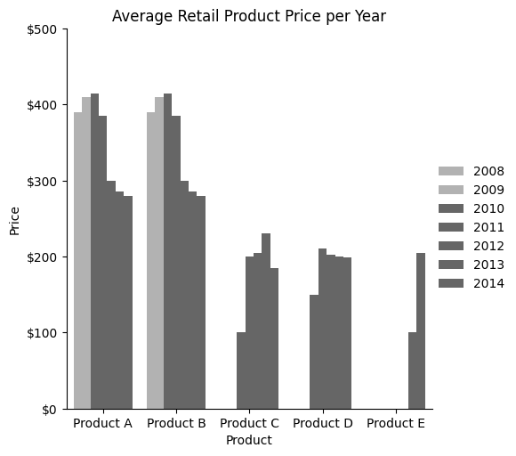

```python
# Figure 8.3 (p. 191)
import seaborn as sns
import matplotlib.ticker as tkr

products = [
    'Product A',
    'Product A',
    'Product A',
    'Product A',
    'Product A',
    'Product A',
    'Product A',
    'Product B',
    'Product B',
    'Product B',
    'Product B',
    'Product B',
    'Product B',
    'Product B',
    'Product C',
    'Product C',
    'Product C',
    'Product C',
    'Product C',
    'Product C',
    'Product C',
    'Product D',
    'Product D',
    'Product D',
    'Product D',
    'Product D',
    'Product D',
    'Product D',
    'Product E',
    'Product E',
    'Product E',
    'Product E',
    'Product E',
    'Product E',
    'Product E',
]
years = [
    # A
    '2008',
    '2009',
    '2010',
    '2011',
    '2012',
    '2013',
    '2014',
    # B
    '2008',
    '2009',
    '2010',
    '2011',
    '2012',
    '2013',
    '2014',
    # C
    '2008',
    '2009',
    '2010',
    '2011',
    '2012',
    '2013',
    '2014',
    # D
    '2008',
    '2009',
    '2010',
    '2011',
    '2012',
    '2013',
    '2014',
    # E
    '2008',
    '2009',
    '2010',
    '2011',
    '2012',
    '2013',
    '2014',
]
prices = [
    # A
    390,
    410,
    415,
    385,
    300,
    285,
    280,
    # B
    390,
    410,
    415,
    385,
    300,
    285,
    280,
    # C
    0,
    0,
    100,
    200,
    205,
    230,
    185,
    # D
    0,
    0,
    150,
    210,
    202,
    200,
    199,
    # E
    0,
    0,
    0,
    0,
    0,
    100,
    205,
]
df = pd.DataFrame({
    'Product': products,
    'Year': years,
    'Price': prices
})

# Draw a nested barplot by species and sex
colors = ["gray", "gray", "black", "black", "black", "black", "black"]

g = sns.catplot(
    data=df, kind="bar",
    x="Product", y="Price", hue="Year",
    palette=colors, alpha=.6,
)
# Apply dollar sign formatting
fmt = '${x:,.0f}' # Adds $ and comma separators
tick = tkr.StrMethodFormatter(fmt)
for ax in g.axes.flat:
    ax.yaxis.set_major_formatter(tick)

plt.ylim(None, 500) # Sets y-max to 100

g.legend.set_title("")
plt.title("Average Retail Product Price per Year")
```